# Document Summarization

Trey Pujats Clarence Williams and Maria Schroeder

11/12/2019

## Document Summarization

Document summarization’s ultimate goal is to identify the most important and mostfrequent text within a document and ouput those results, capturing the best summary of the document. Document summarization can be categorized as either abstractive or extractive. Abstractive document summarization uses semantic relationships between text in the original document and uses natural language processing to generate new text to describe the summarization of the document. Abstractive summarization is generally the way that humans create summaries. Typically document summarization techniques do not use this kind of summarizationbecause problems of semantic representation and others are difficult and currently not easy to deal with. In contrast, extractive ranks the text within the document against one another and then extracts the most important text/ highest ranking textin the document. It chooses a subset of sentences to output verbatim from the original text as the summary. In general the steps of Document Summarization can be summarized as follows:

1.Construct an intermediate representation of the document

2. Score the sentences based on the representation
3. Select a summary of the text using the sentences.

The most common is the text ranking method. The text ranking method breaks the document into text strings of the users choice and measures similarity between these text stuructures (consider them sentences for the purpose of this presentation). Graphically, these sentences create vertices and the frequency of similarity of sentences is measured by edges that connect to vertices within the graph. Furthermore, the edges can have weight to them based on how important the vertex is that is connected to the edge. A vertex of high importance is meaured by its similarity to other vertices and the similarity is measured by lexical or semantic relations to the other text. Rada Mihalcea shows the four steps to perform text ranking in document summarization:

1. Identify text units that best define the task at hand,and add them as vertices in the graph.
2. Identify relations that connect such text units, anduse these relations to draw edges between verticesin the graph. Edges can be directed or undirected,weighted or unweighted.
3. Iterate the graph-based ranking algorithm until convergence.
4. Sort vertices based on their final score. Use the values attached to each vertex for ranking/selection decisions.There are many different ways to score sentences. Methods of scoring use location of words, words in titles, indicator phrases, and/or cue methods. The use of location assumes greater importance to sentences at the beginning and end of sentences. The use of titles heuristics assume a higher importance of sentences that contain keywords from titles. There are certain words that imply or accompany words that help summarize a given report. An example of this may be the phrase “To conclude”. Additionally, cue words can either imply importance of a sentence or its lack of importance. An example of a word that implies greater imporance is “significant”. A word that may imply lesser importance is “hardly”. Based off of these methods, sentences can be scored from these heuristics. In our dataset, sincethere are no subsections and it is not a single large document some of these may not be helpful.

Practical Applications:

One practical application of document summarization is used by Google to summarize webpages. Generate abstracts for documents.

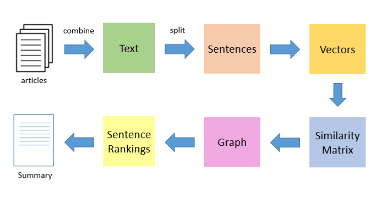

```r
knitr::include_graphics("C:/Users/treyp/OneDrive/Documents/OPER 655 - Text Mining/oper655_fa2019/student_project_folders/oper655_fa2019_pujats/3.png")
```

## Cleaning the Data

Since Captain Brandon Hufstetler cleaned the code for text sentiment, we did not duplicate efforts although we alterred thim to fit the document summarization setup. Instead, we did not unnest each word but kept each review together. This made it easier to categorize the data and evaluate complete sentences rather than words for sentiment. The finished dataset is review_tidy and it is shown below. Next we decided to look at each phone separate from one another. Summaries of different phones from different companies does not capture anything useful to the consumer or the producer in this case. Subsets were created to split the data by phone including the iPhone4, iPhone5, iPhone6, iPhone7, galaxy S5, galaxy s6, galaxy s7, and galaxy s8. Using these subsets, we performed document summarization.

```r
pacman::p_load(tidyr,
               tidytext,
               tidyverse,
               textdata,
               dplyr,
               stringr,
               ggplot2,
               magrittr,
               wordcloud,
               reshape2,
               textmineR,
               LSAfun,
               igraph,
               textrank,
               ggraph,
               lattice,
               udpipe)



root <- rprojroot::find_root(rprojroot::is_rstudio_project)
file_loc <- file.path(root,"data","phone_user_reviews")

file_list <- list.files(path = file_loc,
                        pattern = "",
                        full.names = TRUE)
reviews_tidy <- tibble::tibble()
manu_pattern <- "/cellphones/[a-z0-9]+"
prod_pattern <- paste(manu_pattern, "-|/", sep = "")
for (i in file_list){
  input <- load(i,ex <- new.env())
  text_raw <- get(ls(ex),ex)
  text_en <- text_raw[text_raw$lang=="en",]
  rm(ex, text_raw, input, i)

  clean <- tibble::tibble(score = text_en$score,
                          maxscore = text_en$score_max,
                          text = text_en$extract,
                          product = gsub(prod_pattern, "", text_en$phone_url),
                          author = text_en$author,
                          manufacturer = gsub("/cellphones/","",str_extract(text_en$phone_url,manu_pattern)))

  reviews_tidy <- base::rbind(reviews_tidy, clean)
  rm(text_en, clean)
}
rm(file_list, root, manu_pattern, prod_pattern, file_loc)
head(reviews_tidy)
```

```
## # A tibble: 6 x 6
##   score maxscore text                         product  author  manufacturer
##   <dbl>    <dbl> <chr>                        <chr>    <chr>   <chr>
## 1  10         10 As a diehard Samsung fan wh~ galaxy-~ CarolA~ samsung
## 2  10         10 Love the phone. the phone i~ galaxy-~ james0~ samsung
## 3   6         10 Adequate feel. Nice heft. P~ galaxy-~ R. Cra~ samsung
## 4   9.2       10 Never disappointed. One of ~ galaxy-~ Buster~ samsung
## 5   4         10 I've now found that i'm in ~ galaxy-~ S Ate ~ samsung
## 6  10         10 I am the type of person who~ galaxy-~ BDB76   samsung
```

```r
GalaxyS5<-na.omit(subset(reviews_tidy, reviews_tidy$product=="galaxy-s5"))
GalaxyS6<-na.omit(subset(reviews_tidy, reviews_tidy$product=="galaxy-s6"))
GalaxyS7<-na.omit(subset(reviews_tidy, reviews_tidy$product=="galaxy-s7-edge"))
GalaxyS8<-na.omit(subset(reviews_tidy, reviews_tidy$product=="galaxy-s8"))

iPhone4<-na.omit(subset(reviews_tidy, reviews_tidy$product=="iphone-4"))
iPhone5<-na.omit(subset(reviews_tidy, reviews_tidy$product=="iphone-5"))
iPhone6<-na.omit(subset(reviews_tidy, reviews_tidy$product=="iphone-6"))
iPhone7<-na.omit(subset(reviews_tidy, reviews_tidy$product=="iphone-7"))

WorstReviews<-na.omit(subset(reviews_tidy, reviews_tidy$score<2))
BestReviews<-na.omit(subset(reviews_tidy, reviews_tidy$score>9))
```

## Cell Phone Summarization

```r
#This uses tidy text to create tokens of sentences anf of words from the document. This is necessary to analyze the similarity between sentences, get rid of stop words and to rank the sentences.
article_sentences <- tibble(text = GalaxyS5$text[1:100]) %>%
  unnest_tokens(sentence, text, token = "sentences") %>%
  mutate(sentence_id = row_number()) %>%
  select(sentence_id, sentence)

article_words <- article_sentences %>%
  unnest_tokens(word, sentence)

article_words <- article_words %>%
  anti_join(stop_words, by = "word")

article_summary <- textrank_sentences(data = article_sentences,
                                      terminology = article_words)


#This shows us the top three sentences that summarize the document
article_summary[["sentences"]] %>%
  arrange(desc(textrank)) %>%
  slice(1:3) %>%
  pull(sentence)
```

```
## [1] "i really like this phone."
## [2] "this phone is great!"
## [3] "it has everything i need and i haven't had any problems phone works great!"
```

```r
genericSummary(GalaxyS5$text[1:100],3)
```

[output not shown]

```r
#This examines the lowest rank of sentences that explain the reviews.
article_summary[["sentences"]] %>%
  arrange(textrank) %>%
  slice(1:3) %>%
  pull(sentence)
```

```
## [1] "signed up."
## [2] "everything works great."
## [3] "took some getting used to switching from ios."
```

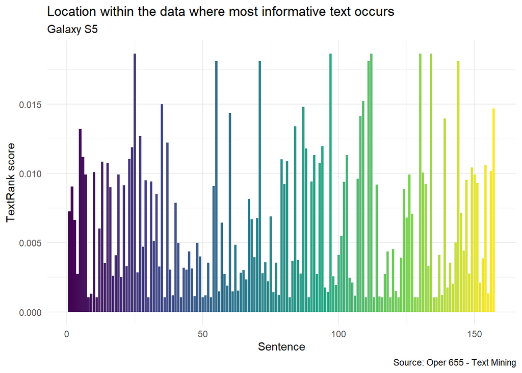

```r
#This shows where, within the document, you see the most important text.
article_summary[["sentences"]] %>%
  ggplot(aes(textrank_id, textrank, fill = textrank_id)) +
  geom_col() +
  theme_minimal() +
  scale_fill_viridis_c() +
  guides(fill = "none") +
  labs(x = "Sentence",
       y = "TextRank score",
       title = "Location within the data where most informative text occurs",
       subtitle = 'Galaxy S5',
       caption = "Source: Oper 655 - Text Mining")
```

```r
#This uses tidy text to create tokens of sentences anf of words from the document. This is necessary to analyze the similarity between sentences, get rid of stop words and to rank the sentences.
article_sentences <- tibble(text = GalaxyS6$text[sample(nrow(GalaxyS6), 100)]) %>%
  unnest_tokens(sentence, text, token = "sentences") %>%
  mutate(sentence_id = row_number()) %>%
  select(sentence_id, sentence)

article_words <- article_sentences %>%
  unnest_tokens(word, sentence)

article_words <- article_words %>%
  anti_join(stop_words, by = "word")

article_summary <- textrank_sentences(data = article_sentences,
                                      terminology = article_words)


#This shows us the top three sentences that summarize the document
article_summary[["sentences"]] %>%
  arrange(desc(textrank)) %>%
  slice(1:3) %>%
  pull(sentence)
```

```
## [1] "the samsung galaxy s6 is overall a good phone."
## [2] "this is my third samsung galaxy phone, and the s6 is by far the best of them all."
## [3] "i love this phone..."
```

```r
#This examines the lowest rank of sentences that explain the reviews.
article_summary[["sentences"]] %>%
  arrange(textrank) %>%
  slice(1:3) %>%
  pull(sentence)
```

```
## [1] "my son's coach loves it too!" "it works good!"
## [3] "not a good combination."
```

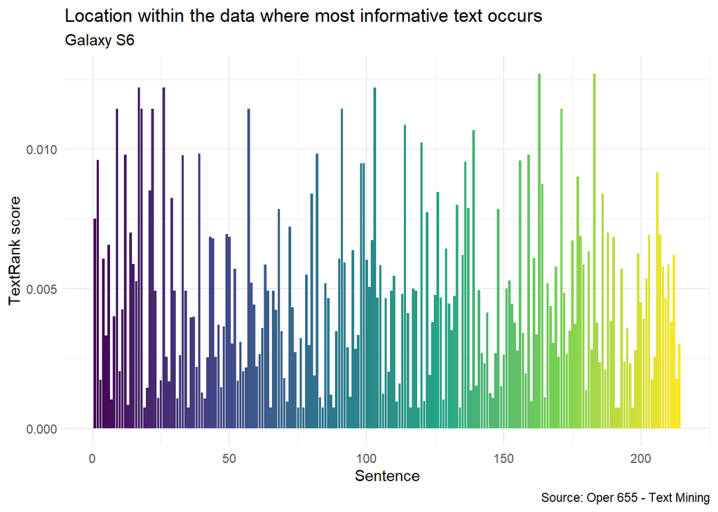

```r
#This shows where, within the document, you see the most important text.
article_summary[["sentences"]] %>%
  ggplot(aes(textrank_id, textrank, fill = textrank_id)) +
  geom_col() +
  theme_minimal() +
  scale_fill_viridis_c() +
  guides(fill = "none") +
  labs(x = "Sentence",
       y = "TextRank score",
       title = "Location within the data where most informative text occurs",
       subtitle = 'Galaxy S6',
       caption = "Source: Oper 655 - Text Mining")
```

```r
#This uses tidy text to create tokens of sentences anf of words from the document. This is necessary to analyze the similarity between sentences, get rid of stop words and to rank the sentences.
article_sentences <- tibble(text = GalaxyS7$text[sample(nrow(GalaxyS7), 100)]) %>%
  unnest_tokens(sentence, text, token = "sentences") %>%
  mutate(sentence_id = row_number()) %>%
  select(sentence_id, sentence)

article_words <- article_sentences %>%
  unnest_tokens(word, sentence)

article_words <- article_words %>%
  anti_join(stop_words, by = "word")

article_summary <- textrank_sentences(data = article_sentences,
                                      terminology = article_words)


#This shows us the top three sentences that summarize the document
article_summary[["sentences"]] %>%
  arrange(desc(textrank)) %>%
  slice(1:3) %>%
  pull(sentence)
```

```
## [1] "i love this phone."            "you'll love this phone."
## [3] "over all i love this phone .."
```

```r
#This examines the lowest rank of sentences that explain the reviews.
article_summary[["sentences"]] %>%
  arrange(textrank) %>%
  slice(1:3) %>%
  pull(sentence)
```

```
## [1] "they both are close as far as the ease of use."
## [2] "it has all of the latest technology that you may need."
## [3] "none."
```

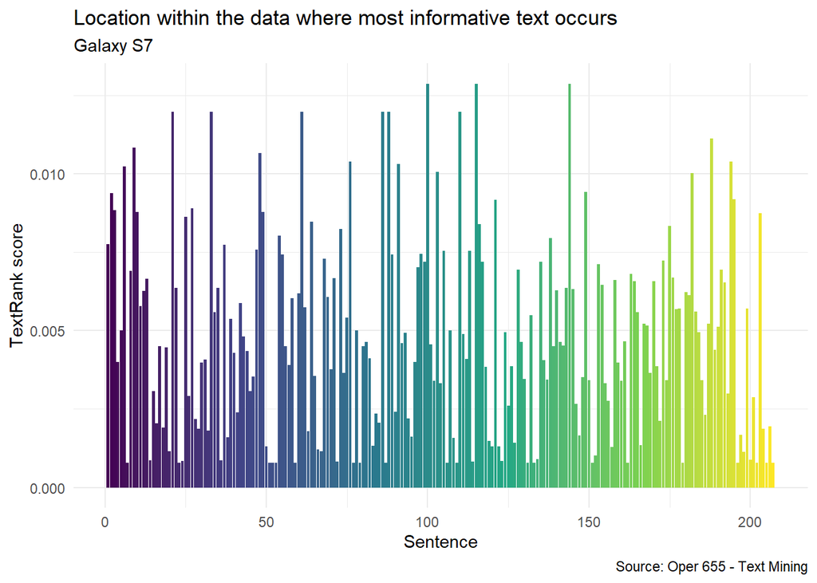

```r
#This shows where, within the document, you see the most important text.
article_summary[["sentences"]] %>%
  ggplot(aes(textrank_id, textrank, fill = textrank_id)) +
  geom_col() +
  theme_minimal() +
  scale_fill_viridis_c() +
  guides(fill = "none") +
  labs(x = "Sentence",
       y = "TextRank score",
       title = "Location within the data where most informative text occurs",
       subtitle = 'Galaxy S7',
       caption = "Source: Oper 655 - Text Mining")
```

```r
#This uses tidy text to create tokens of sentences anf of words from the document. This is necessary to analyze the similarity between sentences, get rid of stop words and to rank the sentences.
article_sentences <- tibble(text = GalaxyS8$text[sample(nrow(GalaxyS8), 100)]) %>%
  unnest_tokens(sentence, text, token = "sentences") %>%
  mutate(sentence_id = row_number()) %>%
  select(sentence_id, sentence)

article_words <- article_sentences %>%
  unnest_tokens(word, sentence)

article_words <- article_words %>%
  anti_join(stop_words, by = "word")

article_summary <- textrank_sentences(data = article_sentences,
                                      terminology = article_words)


#This shows us the top three sentences that summarize the document
article_summary[["sentences"]] %>%
  arrange(desc(textrank)) %>%
  slice(1:3) %>%
  pull(sentence)
```

```
## [1] "best phone i have used ever."
## [2] "it was like i still was using my old phone."
## [3] "overall a great phone."
```

```r
#This examines the lowest rank of sentences that explain the reviews.
article_summary[["sentences"]] %>%
  arrange(textrank) %>%
  slice(1:3) %>%
  pull(sentence)
```

```
## [1] "has no problem multitasking." "debating whether to keep it."
## [3] "if you can get one, do."
```

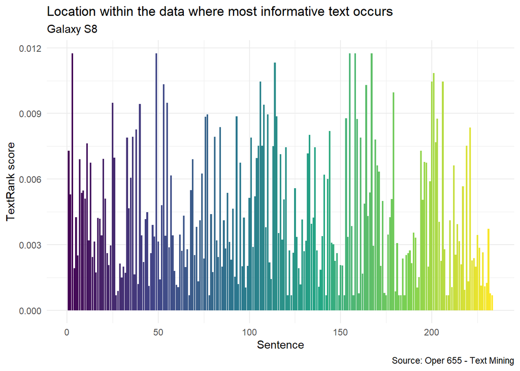

```r
#This shows where, within the document, you see the most important text.
article_summary[["sentences"]] %>%
  ggplot(aes(textrank_id, textrank, fill = textrank_id)) +
  geom_col() +
  theme_minimal() +
  scale_fill_viridis_c() +
  guides(fill = "none") +
  labs(x = "Sentence",
       y = "TextRank score",
       title = "Location within the data where most informative text occurs",
       subtitle = 'Galaxy S8',
       caption = "Source: Oper 655 - Text Mining")
```

```r
#This uses tidy text to create tokens of sentences anf of words from the document. This is necessary to analyze the similarity between sentences, get rid of stop words and to rank the sentences.
article_sentences <- tibble(text = iPhone4$text[sample(nrow(iPhone4), 100)]) %>%
  unnest_tokens(sentence, text, token = "sentences") %>%
  mutate(sentence_id = row_number()) %>%
  select(sentence_id, sentence)

article_words <- article_sentences %>%
  unnest_tokens(word, sentence)

article_words <- article_words %>%
  anti_join(stop_words, by = "word")

article_summary <- textrank_sentences(data = article_sentences,
                                      terminology = article_words)


#This shows us the top three sentences that summarize the document
article_summary[["sentences"]] %>%
  arrange(desc(textrank)) %>%
  slice(1:3) %>%
  pull(sentence)
```

```
## [1] "the phone was everything that it said and works great."
## [2] "phone is not clear!"
## [3] "so don't buy this phone."
```

```r
#This examines the lowest rank of sentences that explain the reviews.
article_summary[["sentences"]] %>%
  arrange(textrank) %>%
  slice(1:3) %>%
  pull(sentence)
```

```
## [1] "i ordered two of these, one for me and the other for my sister."
## [2] "what more can you ask for?"
## [3] "i do not suggest this site."
```

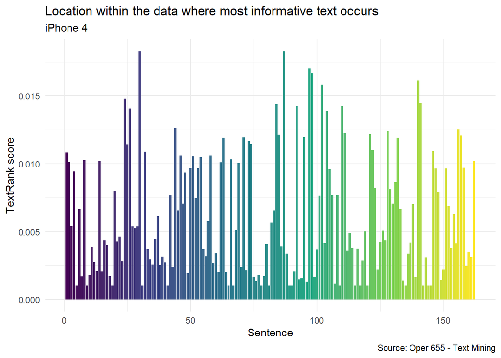

```r
#This shows where, within the document, you see the most important text.
article_summary[["sentences"]] %>%
  ggplot(aes(textrank_id, textrank, fill = textrank_id)) +
  geom_col() +
  theme_minimal() +
  scale_fill_viridis_c() +
  guides(fill = "none") +
  labs(x = "Sentence",
       y = "TextRank score",
       title = "Location within the data where most informative text occurs",
       subtitle = 'iPhone 4',
       caption = "Source: Oper 655 - Text Mining")
```

```r
#This uses tidy text to create tokens of sentences anf of words from the document. This is necessary to analyze the similarity between sentences, get rid of stop words and to rank the sentences.
article_sentences <- tibble(text = iPhone5$text[sample(nrow(iPhone5), 100)]) %>%
  unnest_tokens(sentence, text, token = "sentences") %>%
  mutate(sentence_id = row_number()) %>%
  select(sentence_id, sentence)

article_words <- article_sentences %>%
  unnest_tokens(word, sentence)

article_words <- article_words %>%
  anti_join(stop_words, by = "word")

article_summary <- textrank_sentences(data = article_sentences,
                                      terminology = article_words)


#This shows us the top three sentences that summarize the document
article_summary[["sentences"]] %>%
  arrange(desc(textrank)) %>%
  slice(1:3) %>%
  pull(sentence)
```

```
## [1] "the phone was okay."
## [2] "great phone!!"
## [3] "this phone has some kind of malfunction with the battery."
```

```r
#This examines the lowest rank of sentences that explain the reviews.
article_summary[["sentences"]] %>%
  arrange(textrank) %>%
  slice(1:3) %>%
  pull(sentence)
```

```
## [1] "dissapointed i gave it a 4.5 because there's always room for improvement."
## [2] "it could have nfc capabilities-- even though no one is really utilizing that yet."
## [3] "is there any solution ?"
```

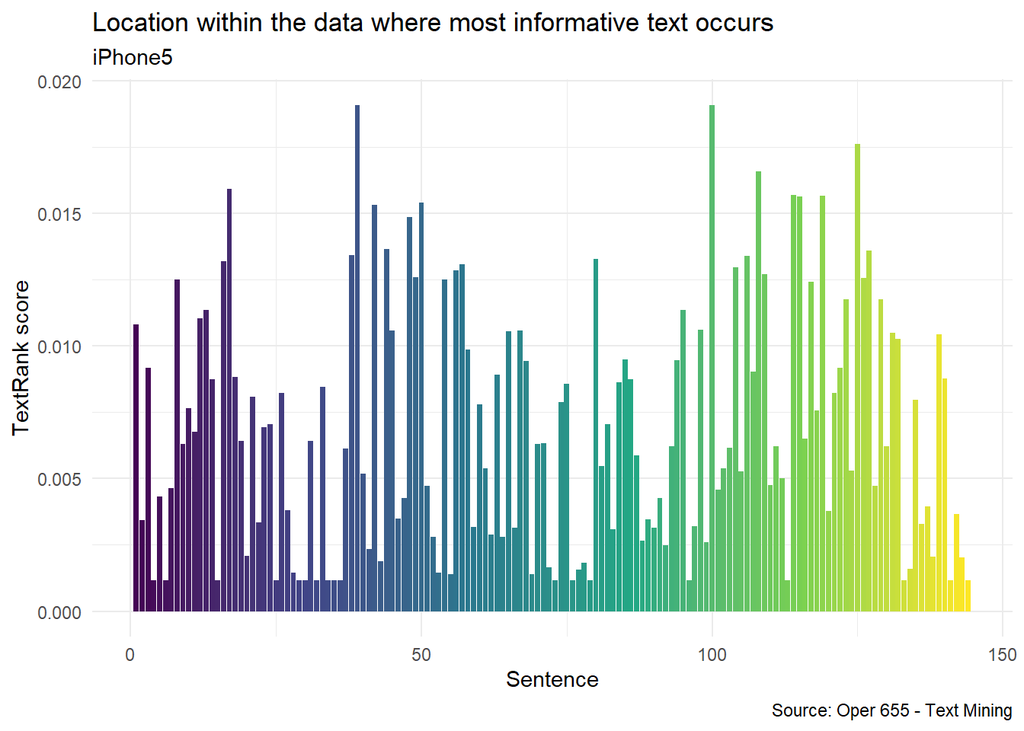

```r
#This shows where, within the document, you see the most important text.
article_summary[["sentences"]] %>%
  ggplot(aes(textrank_id, textrank, fill = textrank_id)) +
  geom_col() +
  theme_minimal() +
  scale_fill_viridis_c() +
  guides(fill = "none") +
  labs(x = "Sentence",
       y = "TextRank score",
       title = "Location within the data where most informative text occurs",
       subtitle = 'iPhone5',
       caption = "Source: Oper 655 - Text Mining")
```

```r
#This uses tidy text to create tokens of sentences anf of words from the document. This is necessary to analyze the similarity between sentences, get rid of stop words and to rank the sentences.
article_sentences <- tibble(text = iPhone6$text[sample(nrow(iPhone6), 100)]) %>%
  unnest_tokens(sentence, text, token = "sentences") %>%
  mutate(sentence_id = row_number()) %>%
  select(sentence_id, sentence)

article_words <- article_sentences %>%
  unnest_tokens(word, sentence)

article_words <- article_words %>%
  anti_join(stop_words, by = "word")

article_summary <- textrank_sentences(data = article_sentences,
                                      terminology = article_words)


#This shows us the top three sentences that summarize the document
article_summary[["sentences"]] %>%
  arrange(desc(textrank)) %>%
  slice(1:3) %>%
  pull(sentence)
```

```
## [1] "great phone!"
## [2] "i love my phone!"
## [3] "this review is for the iphone 6 (4.7”) phone."
```

```r
#This examines the lowest rank of sentences that explain the reviews.
article_summary[["sentences"]] %>%
  arrange(textrank) %>%
  slice(1:3) %>%
  pull(sentence)
```

```
## [1] "worked right on the spot."
## [2] "but i have been unable to use the gps."
## [3] "they couldn't fix it."
```

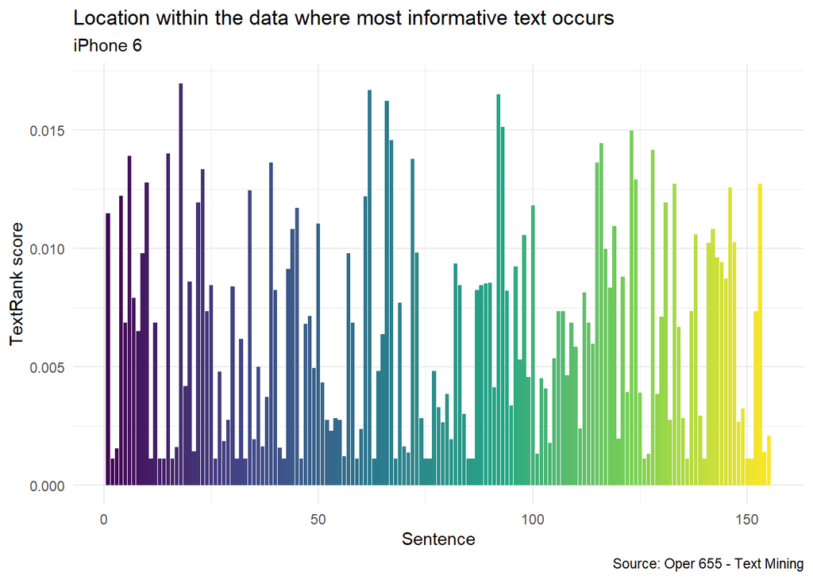

```r
#This shows where, within the document, you see the most important text.
article_summary[["sentences"]] %>%
  ggplot(aes(textrank_id, textrank, fill = textrank_id)) +
  geom_col() +
  theme_minimal() +
  scale_fill_viridis_c() +
  guides(fill = "none") +
  labs(x = "Sentence",
       y = "TextRank score",
       title = "Location within the data where most informative text occurs",
       subtitle = 'iPhone 6',
       caption = "Source: Oper 655 - Text Mining")
```

```r
#This uses tidy text to create tokens of sentences anf of words from the document. This is necessary to analyze the similarity between sentences, get rid of stop words and to rank the sentences.
article_sentences <- tibble(text = iPhone7$text[sample(nrow(iPhone7), 100)]) %>%
  unnest_tokens(sentence, text, token = "sentences") %>%
  mutate(sentence_id = row_number()) %>%
  select(sentence_id, sentence)

article_words <- article_sentences %>%
  unnest_tokens(word, sentence)

article_words <- article_words %>%
  anti_join(stop_words, by = "word")

article_summary <- textrank_sentences(data = article_sentences,
                                      terminology = article_words)


#This shows us the top three sentences that summarize the document
article_summary[["sentences"]] %>%
  arrange(desc(textrank)) %>%
  slice(1:3) %>%
  pull(sentence)
```

```
## [1] "the iphone 7 is in many ways a better phone."
## [2] "went from an iphone 6 to an iphone 7 love the phone!!"
## [3] "he desperately needed a new phone so i treated him to the iphone 7."
```

```r
#This examines the lowest rank of sentences that explain the reviews.
article_summary[["sentences"]] %>%
  arrange(textrank) %>%
  slice(1:3) %>%
  pull(sentence)
```

```
## [1] "what can i say?"        "excuses can be enough."
## [3] "great deal..."
```

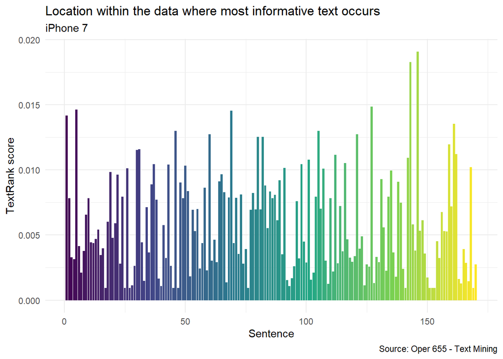

```r
#This shows where, within the document, you see the most important text.
article_summary[["sentences"]] %>%
  ggplot(aes(textrank_id, textrank, fill = textrank_id)) +
  geom_col() +
  theme_minimal() +
  scale_fill_viridis_c() +
  guides(fill = "none") +
  labs(x = "Sentence",
       y = "TextRank score",
       title = "Location within the data where most informative text occurs",
       subtitle = 'iPhone 7',
       caption = "Source: Oper 655 - Text Mining")
```

```r
#This uses tidy text to create tokens of sentences anf of words from the document. This is necessary to analyze the similarity between sentences, get rid of stop words and to rank the sentences.
article_sentences <- tibble(text = BestReviews$text[sample(nrow(BestReviews), 100)]) %>%
  unnest_tokens(sentence, text, token = "sentences") %>%
  mutate(sentence_id = row_number()) %>%
  select(sentence_id, sentence)

article_words <- article_sentences %>%
  unnest_tokens(word, sentence)

article_words <- article_words %>%
  anti_join(stop_words, by = "word")

article_summary <- textrank_sentences(data = article_sentences,
                                      terminology = article_words)


#This shows us the top three sentences that summarize the document
article_summary[["sentences"]] %>%
  arrange(desc(textrank)) %>%
  slice(1:3) %>%
  pull(sentence)
```

```
## [1] "best phone work for working."
## [2] "i cant say enough about this phone."
## [3] "i thought it was all right until i got this phone."
```

```r
#This examines the lowest rank of sentences that explain the reviews.
article_summary[["sentences"]] %>%
  arrange(textrank) %>%
  slice(1:3) %>%
  pull(sentence)
```

```
## [1] "the g4 manages to carve out a niche for itself, with a different offering from the s6 or m9."
## [2] "thanks!!!"
## [3] "i used to have 7510 on nextel."
```

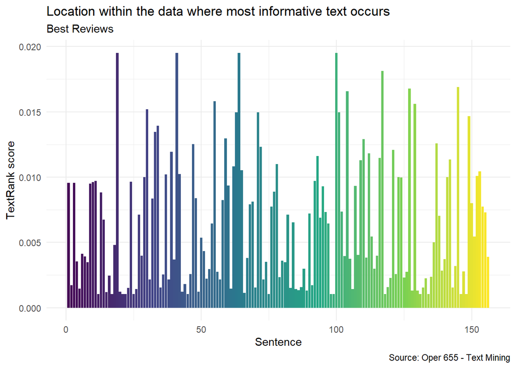

```r
#This shows where, within the document, you see the most important text.
article_summary[["sentences"]] %>%
  ggplot(aes(textrank_id, textrank, fill = textrank_id)) +
  geom_col() +
  theme_minimal() +
  scale_fill_viridis_c() +
  guides(fill = "none") +
  labs(x = "Sentence",
       y = "TextRank score",
       title = "Location within the data where most informative text occurs",
       subtitle = 'Best Reviews',
       caption = "Source: Oper 655 - Text Mining")
```

```r
#This uses tidy text to create tokens of sentences anf of words from the document. This is necessary to analyze the similarity between sentences, get rid of stop words and to rank the sentences.
article_sentences <- tibble(text = WorstReviews$text[sample(nrow(WorstReviews), 100)]) %>%
  unnest_tokens(sentence, text, token = "sentences") %>%
  mutate(sentence_id = row_number()) %>%
  select(sentence_id, sentence)

article_words <- article_sentences %>%
  unnest_tokens(word, sentence)

article_words <- article_words %>%
  anti_join(stop_words, by = "word")

article_summary <- textrank_sentences(data = article_sentences,
                                      terminology = article_words)


#This shows us the top three sentences that summarize the document
article_summary[["sentences"]] %>%
  arrange(desc(textrank)) %>%
  slice(1:3) %>%
  pull(sentence)
```

```
## [1] "i had so many problems with this phone."
## [2] "we've both had this phone for about a year."
## [3] "i hate my phone."
```

```r
#This examines the lowest rank of sentences that explain the reviews.
article_summary[["sentences"]] %>%
  arrange(textrank) %>%
  slice(1:3) %>%
  pull(sentence)
```

```
## [1] "they say it has 512 mb ram, but in badasi it shows only 73 mb available."
## [2] "it's desirability?"
## [3] "t be more let down."
```

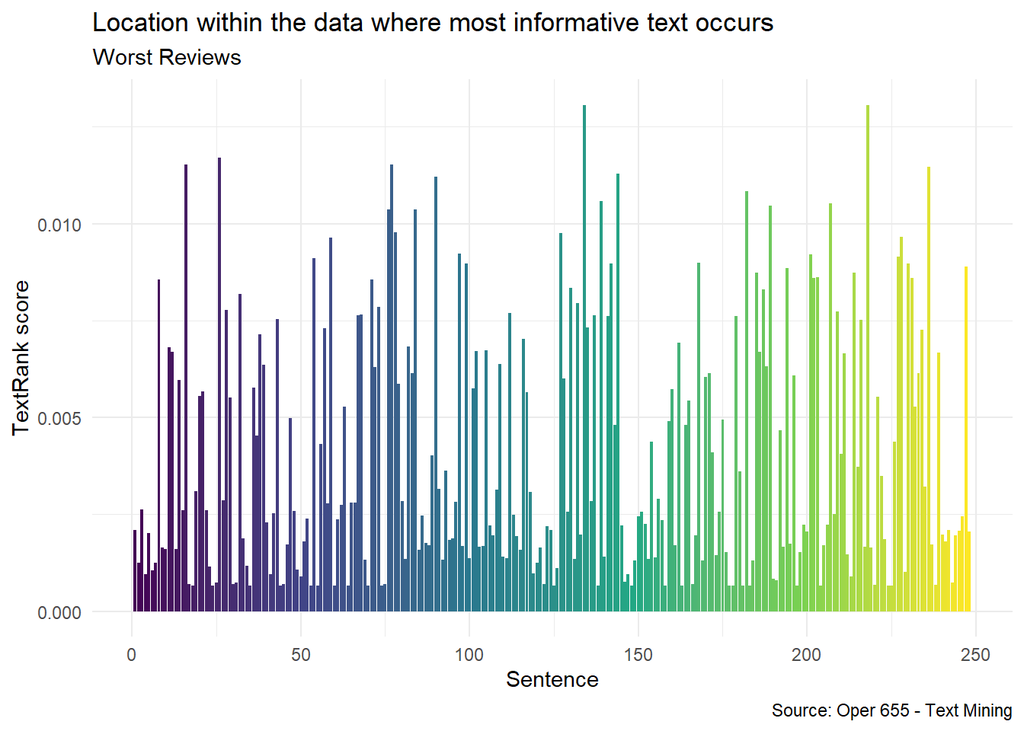

```r
#This shows where, within the document, you see the most important text.
article_summary[["sentences"]] %>%
  ggplot(aes(textrank_id, textrank, fill = textrank_id)) +
  geom_col() +
  theme_minimal() +
  scale_fill_viridis_c() +
  guides(fill = "none") +
  labs(x = "Sentence",
       y = "TextRank score",
       title = "Location within the data where most informative text occurs",
       subtitle = 'Worst Reviews',
       caption = "Source: Oper 655 - Text Mining")
```

## Keyword Extraction

Keyword extraction is a helpful tool to documetn summarization. If you have a very large document and your summarization turns out to be a few pages in length still, keywords could help identify what you need to look for within the summary as well. There are a number of ways to extract keywords, either singularly or as bigrams. We begin by annotating the text, using “udpipe”. This tool allows us to quickly go through all of the text and annotate each word shown in x. We then get a quick idea of the most common words used. This allows us to see what words we can expect and the most common words in our document. Here we specifically look at nouns, which are more common to be keywords compared to adjectives and verbs.

```r
library(udpipe)
library(textrank)
## First step: Take the English udpipe model and annotate the text.
ud_model <- udpipe_download_model(language = "english")
```

```
## Visit https://github.com/jwijffels/udpipe.models.ud.2.4 for model license details
```

```r
ud_model <- udpipe_load_model(ud_model$file_model)
x <- udpipe_annotate(ud_model, x = GalaxyS5$text)
x <- as.data.frame(x)
head(x)
```

```
##   doc_id paragraph_id sentence_id
## 1   doc1            1           1
## 2   doc1            1           1
## 3   doc1            1           1
## 4   doc1            1           1
## 5   doc1            1           1
## 6   doc1            1           1
##                                                                                                                                                                   sentence
## 1 A new review on an old phone which I've resurected as a temporary device (while replacing a new Huawei Mate 9 which is bascially an expensive brick with a nice camera).
## 2 A new review on an old phone which I've resurected as a temporary device (while replacing a new Huawei Mate 9 which is bascially an expensive brick with a nice camera).
## 3 A new review on an old phone which I've resurected as a temporary device (while replacing a new Huawei Mate 9 which is bascially an expensive brick with a nice camera).
## 4 A new review on an old phone which I've resurected as a temporary device (while replacing a new Huawei Mate 9 which is bascially an expensive brick with a nice camera).
## 5 A new review on an old phone which I've resurected as a temporary device (while replacing a new Huawei Mate 9 which is bascially an expensive brick with a nice camera).
## 6 A new review on an old phone which I've resurected as a temporary device (while replacing a new Huawei Mate 9 which is bascially an expensive brick with a nice camera).
##   token_id  token  lemma upos xpos                     feats head_token_id
## 1        1      A      a  DET   DT Definite=Ind|PronType=Art             3
## 2        2    new    new  ADJ   JJ                Degree=Pos             3
## 3        3 review review NOUN   NN               Number=Sing             0
## 4        4     on     on  ADP   IN                      <NA>             7
## 5        5     an      a  DET   DT Definite=Ind|PronType=Art             7
## 6        6    old    old  ADJ   JJ                Degree=Pos             7
##   dep_rel deps misc
## 1     det <NA> <NA>
## 2    amod <NA> <NA>
## 3    root <NA> <NA>
## 4    case <NA> <NA>
## 5     det <NA> <NA>
## 6    amod <NA> <NA>
```

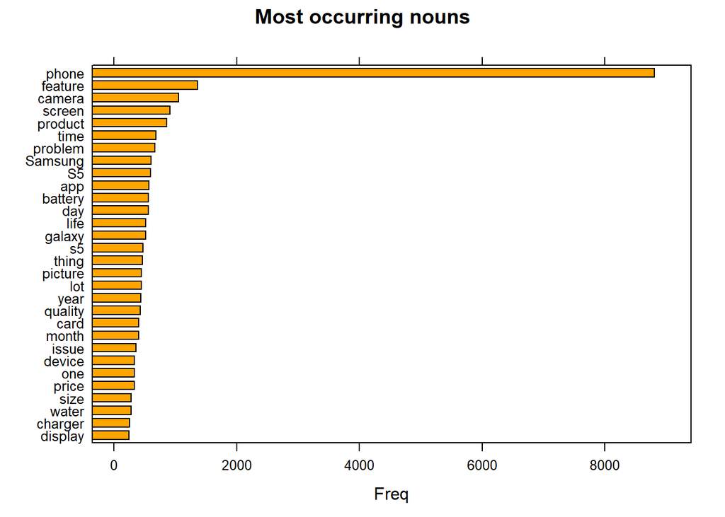

```r
#Lemma is just the column of all of the words in the document
#Here we simply show the frequency of the words.
stats <- subset(x, upos %in% "NOUN")
stats <- txt_freq(x = stats$lemma)
library(lattice)
stats$key <- factor(stats$key, levels = rev(stats$key))
barchart(key ~ freq, data = head(stats, 30), col = "orange", main = "Most occurring nouns", xlab = "Freq")
```

Next we may want to look at expressions, since singular words can be misleading out of context. Allowing for expressions could give a better sense of what the documetn is about. We check for concurrences where the two words are directly next to each other, in the same sentence, or a few words away from each other.

```r
## Collocation (words following one another)
stats <- keywords_collocation(x = x,
                              term = "token", group = c("doc_id", "paragraph_id", "sentence_id"),
                              ngram_max = 4)
## Co-occurrences: How frequent do words occur in the same sentence, in this case only nouns or adjectives
stats <- cooccurrence(x = subset(x, upos %in% c("NOUN", "ADJ")),
                      term = "lemma", group = c("doc_id", "paragraph_id", "sentence_id"))
## Co-occurrences: How frequent do words follow one another
stats <- cooccurrence(x = x$lemma,
                      relevant = x$upos %in% c("NOUN", "ADJ"))
## Co-occurrences: How frequent do words follow one another even if we would skip 2 words in between
stats <- cooccurrence(x = x$lemma,
                      relevant = x$upos %in% c("NOUN", "ADJ"), skipgram = 2)
head(stats)
```

```
##     term1 term2 cooc
## 1   great phone  678
## 2   phone great  385
## 3 battery  life  365
## 4    best phone  361
## 5     new phone  235
## 6    good phone  227
```

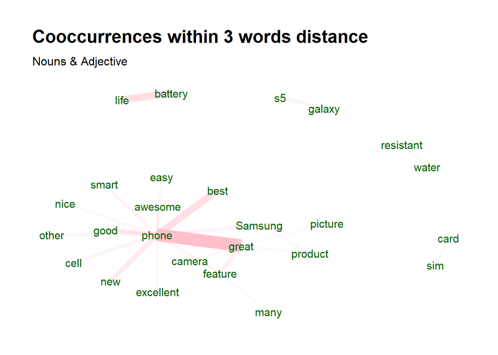

```r
#From here we build out a word network showing how closely related and used together multi word phrases are in the document.
wordnetwork <- head(stats, 30)
wordnetwork <- graph_from_data_frame(wordnetwork)
ggraph(wordnetwork, layout = "fr") +
  geom_edge_link(aes(width = cooc, edge_alpha = cooc), edge_colour = "pink") +
  geom_node_text(aes(label = name), col = "darkgreen", size = 4) +
  theme_graph(base_family = "Arial Narrow") +
  theme(legend.position = "none") +
  labs(title = "Cooccurrences within 3 words distance", subtitle = "Nouns & Adjective")
```

Text ranking is another useful tool to understand the document. This is very similar to determining the highest rank of sentences in document summarization, but this is applied to multiword expressions instead. The word cloud shows the most frequently occuring phrases, only the top 200 expressions.

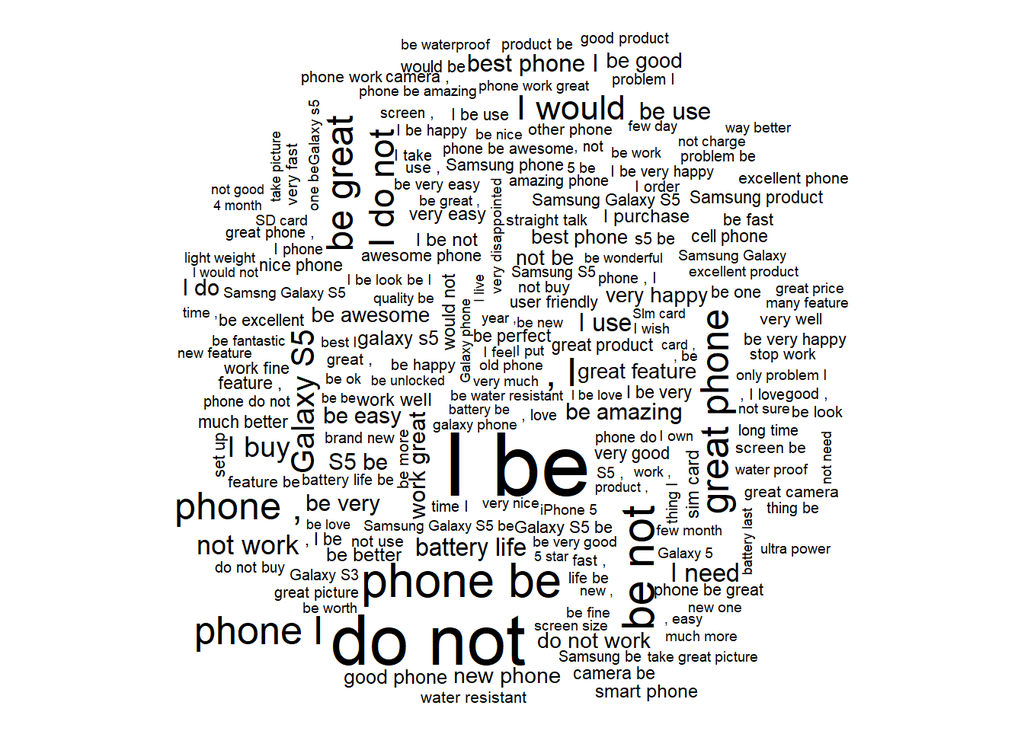

```r
stats <- textrank_keywords(x$lemma,
                           relevant = x$upos %in% c("NOUN", "ADJ"),
                           ngram_max = 8, sep = " ")
stats <- subset(stats$keywords, ngram > 1 & freq >= 5)
library(wordcloud)
wordcloud(words = stats$keyword, freq = stats$freq, max.words = 200)
```

Rapid automatic keyword extraction (RAKE) is very similar to text ranking but it also adds an element of tfidf to its calculations. It still ranks the expressions based on how many times it occurs with other words vs the frequency of occurences in the document. From out data, we can see that it did not provide much help, but given other datasets it could be beneficial to see certain phrases that are mentioned significantly together and not separatlely. It is obvious that in our dataset, we expect to see “Samsung Galaxy” right next to each other and not apart, unless we begin to speak about constellations in our galaxy.

```r
stats <- keywords_rake(x = x,
                       term = "token", group = c("doc_id", "paragraph_id", "sentence_id"),
                       relevant = x$upos %in% c("NOUN", "ADJ"),
                       ngram_max = 4)
head(subset(stats, freq > 3))
```

```
##                  keyword ngram freq     rake
## 2     heart rate monitor     3   29 5.271686
## 3   shopping carts sites     3    5 5.261364
## 4 Indian consumer courts     3    5 5.079545
## 5      heart rate sensor     3    7 5.012036
## 8          micro SD card     3    7 4.490615
## 9           SD card slot     3    4 4.381575
```

```r
## Simple noun phrases (a adjective+noun, pre/postposition, optional determiner and another adjective+noun)
x$phrase_tag <- as_phrasemachine(x$upos, type = "upos")
stats <- keywords_phrases(x = x$phrase_tag, term = x$token,
                          pattern = "(A|N)+N(P+D*(A|N)*N)*",
                          is_regex = TRUE, ngram_max = 4, detailed = FALSE)
head(subset(stats, ngram > 2))
```

```
##               keyword ngram freq
## 14  Samsung Galaxy S5     3  140
## 16       best phone I     3  115
## 41       my new phone     3   59
## 60       my Galaxy S5     3   46
## 92  Samsung galaxy s5     3   35
## 104 my Samsung Galaxy     3   32
```

Lastly, we identify the most common phrases in the dataset to get a feel for the overall docuement.

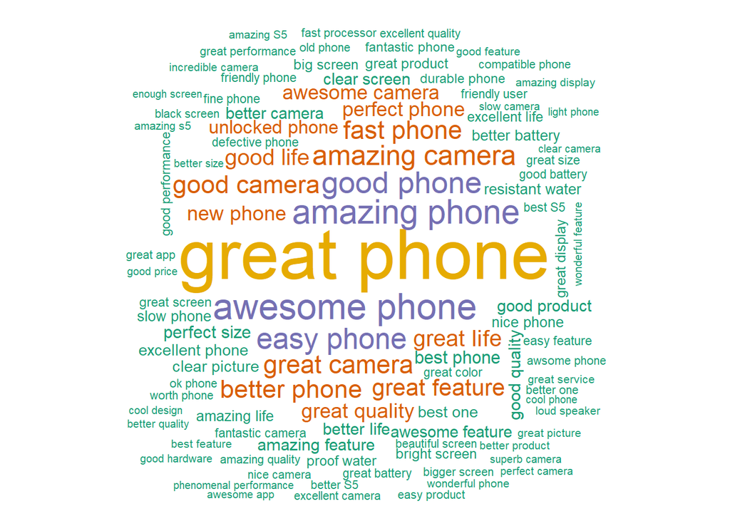

```r
stats <- merge(x, x,
               by.x = c("doc_id", "paragraph_id", "sentence_id", "head_token_id"),
               by.y = c("doc_id", "paragraph_id", "sentence_id", "token_id"),
               all.x = TRUE, all.y = FALSE,
               suffixes = c("", "_parent"), sort = FALSE)
stats <- subset(stats, dep_rel %in% "nsubj" & upos %in% c("NOUN") & upos_parent %in% c("ADJ"))
stats$term <- paste(stats$lemma_parent, stats$lemma, sep = " ")
stats <- txt_freq(stats$term)
library(wordcloud)
wordcloud(words = stats$key, freq = stats$freq, min.freq = 3, max.words = 100,
          random.order = FALSE, colors = brewer.pal(6, "Dark2"))
```